# Exploratory: Optimal Resolution

Courtney R Armour

updated: 2021-03-25

## Table of Contents

- Input data overview
- Hyperparameter Performance
- Model Performance
- DADA2 Comparison

## Input data overview

To total number of samples and features before and after preprocessing for each taxnomic level.

| level | n_samples | n_features | n_features_preproc |
| --- | --- | --- | --- |
| phylum | 490 | 19 | 9 |
| class | 490 | 36 | 19 |
| order | 490 | 65 | 28 |
| family | 490 | 124 | 54 |
| genus | 490 | 316 | 115 |
| otu | 490 | 20079 | 705 |
| asv | 490 | 104106 | 478 |

## Hyperparameter Performance

Plots of HP performance for each model/taxonomic level

### Random Forest

The default hyperparameter (mtry) selection for RF is:

1. sqrt_features / 2
2. sqrt_features
3. sqrt_features * 2

Based on previous results, I added mtry=1 for Phylum through Genus levels and mtry=100 for OTU and ASV levels. This set of hyperparameters seems to cover the optimal range for each taxonomic level.

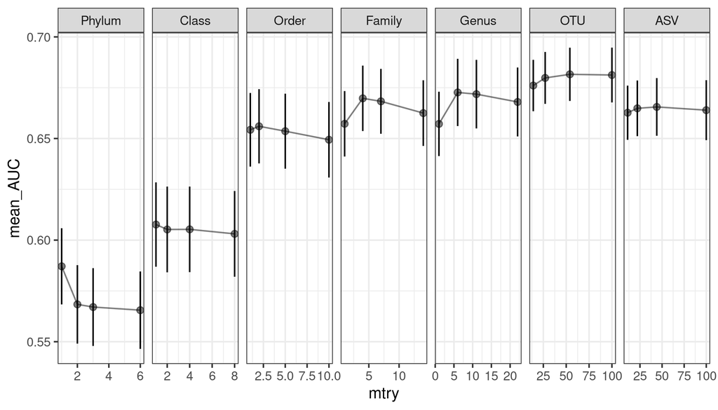

### Logistic Regression

Two metrics: alpha and lambda  
By default alpha is set to zero (for L2 regularization) and lambda values are: 1e-04, 1e-03, 1e-02, 1e-01, 1e+00, 1e+01 I added 1e-05 as a lambda value for phylum and class, and higher values of lambda for the rest

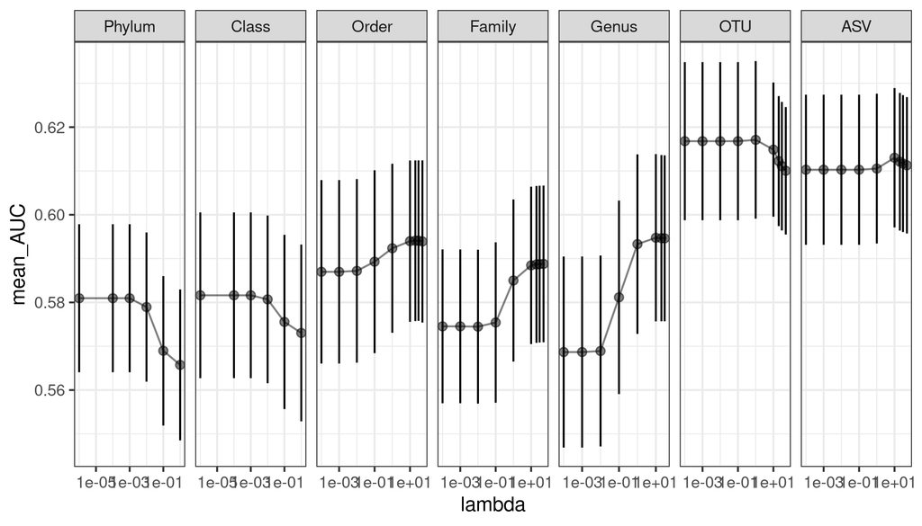

### Decision Tree

The default hyperparameters were retained for decision tree (maxdepth = 1 2 4 8 16 30). It would not allow larger maxdepth than 30.

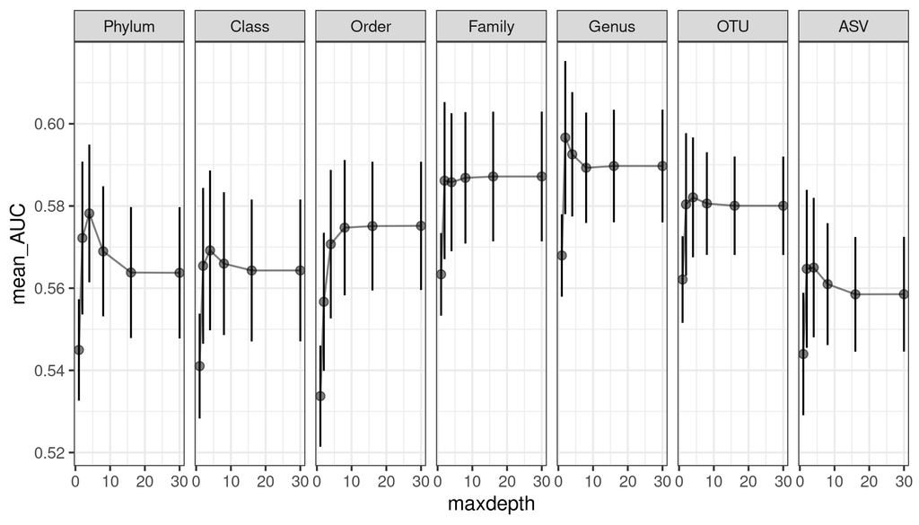

### XGBoost

(needs adjustment)

### SVM Radial

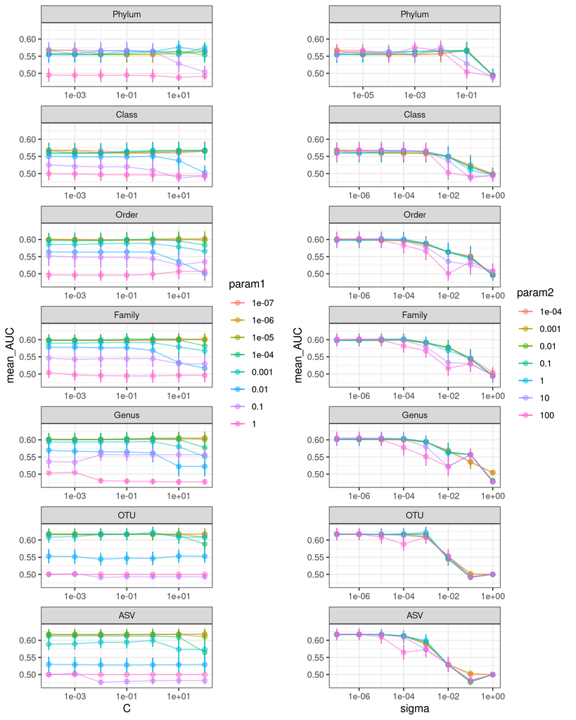

## Model Performance

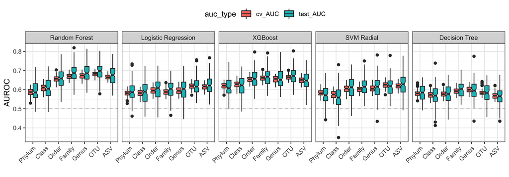

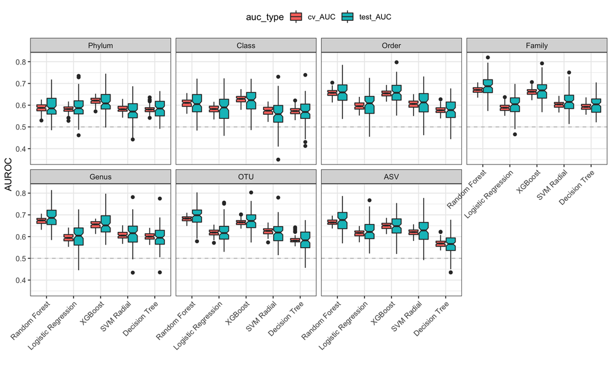

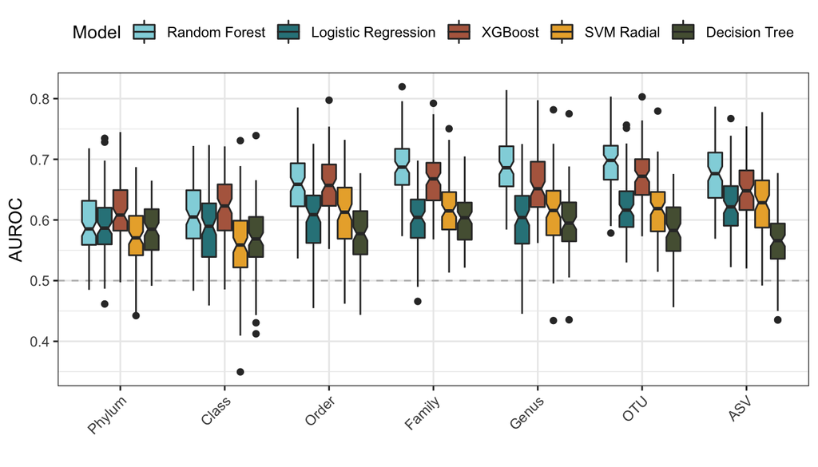

### DADA2 Comparison

| level | n_samples | n_features | n_features_preproc |
| --- | --- | --- | --- |
| phylum | 490 | 19 | 9 |
| class | 490 | 36 | 19 |
| order | 490 | 65 | 28 |
| family | 490 | 124 | 54 |
| genus | 490 | 316 | 115 |
| otu | 490 | 20079 | 705 |
| asv | 490 | 104106 | 478 |
| dada2 | 490 | 9204 | 288 |

### Random Forest Model Performance with Significance

Random Forest on OTU level data yields the highest median AUC, followed by Family, Genus, and ASV. While the OTU AUC is not significantly higher than that of Family or Genus level, it is significantly higher than ASV.

| Level | Median AUC |
| --- | --- |
| phylum | 0.585 |
| class | 0.605 |
| order | 0.659 |
| family | 0.687 |
| genus | 0.686 |
| otu | 0.698 |
| asv | 0.676 |

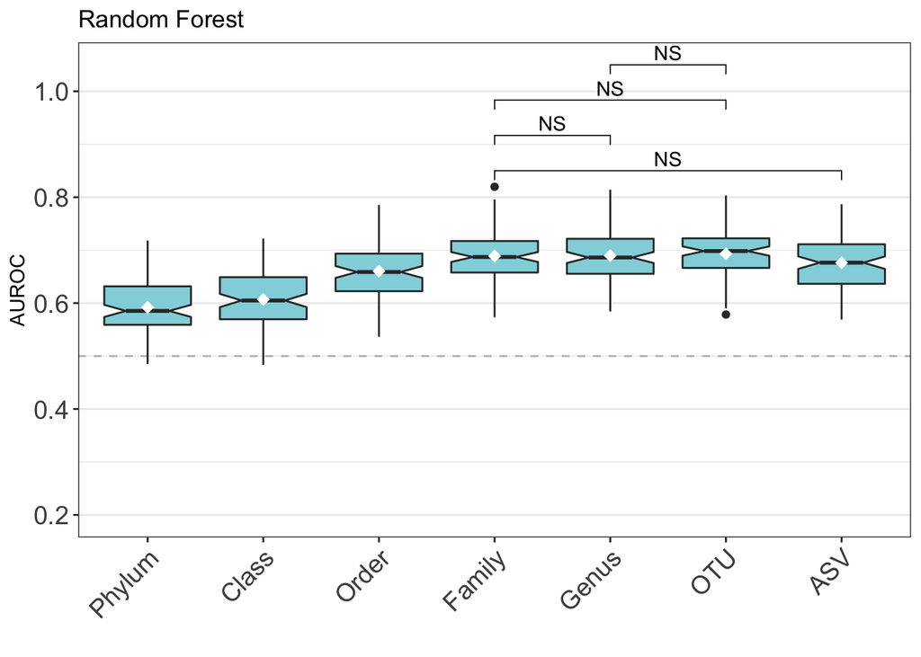

### Logistic Regression Model Performance with Significance

| Level | Median AUC |
| --- | --- |
| phylum | 0.587 |
| class | 0.590 |
| order | 0.609 |
| family | 0.604 |
| genus | 0.604 |
| otu | 0.616 |
| asv | 0.622 |

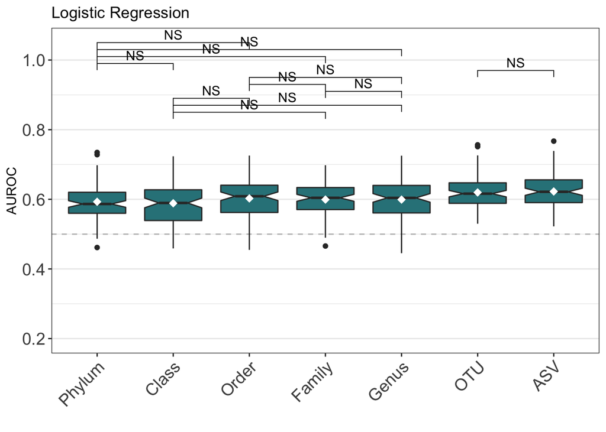

### Decision Tree Model Performance with Significance

| Level | Median AUC |
| --- | --- |
| phylum | 0.585 |
| class | 0.569 |
| order | 0.577 |
| family | 0.604 |
| genus | 0.595 |
| otu | 0.583 |
| asv | 0.566 |

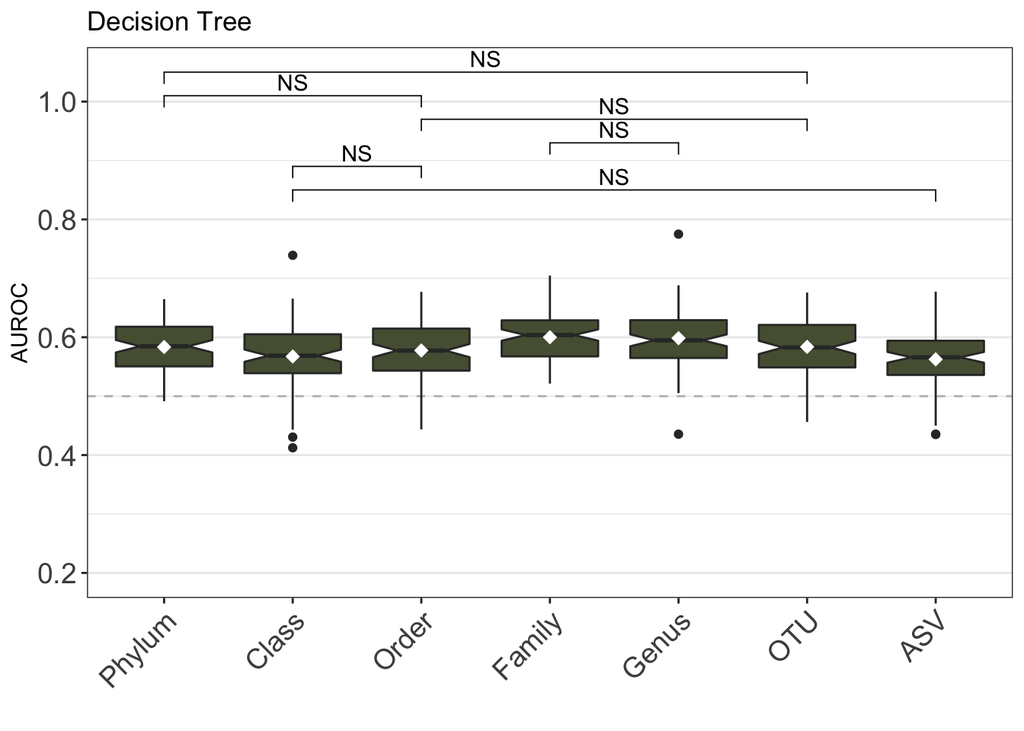

## Feature Importance

The mikropml packages includes an option for finding [feature importance](http://www.schlosslab.org/mikropml/reference/get_feature_importance.html) using a permutation method. This significantly increases the time to run the models. The function permutes each model feature (e.g. genus) and recalulates the AUC with that feature permuted. The outputs are the permuted AUC value and the difference between this AUC value and the actual AUC value. Larger positive differences can be interpreted as being more important since the AUC value is smaller when this feature is permuted.